# QTM 151 - Introduction to Stats Computing II

Lecture 16 - Merging Data

Danilo Freire

danilo.freire@emory.edu

Emory University

28 October, 2024

# Hope your week is off to a good start 😊

# Brief recap 📚

## Last week we saw:

- How to aggregate data using Pandas using the `.agg()` method
- How to combine `.agg()` with `.groupby()`
- Use `.query()` to filter and summarise data
- Note: assignment 07 has been marked and feedback provided
- Assignment 08 is due on Friday

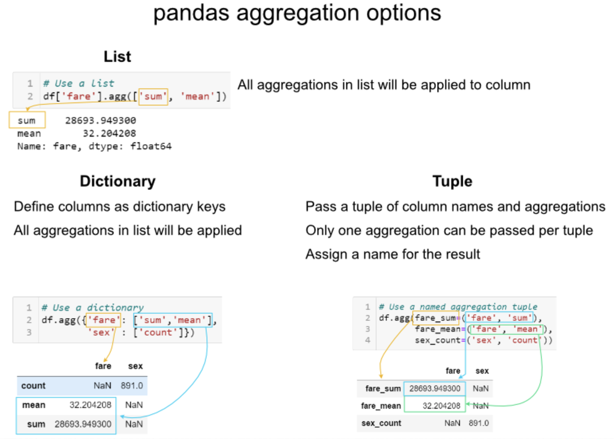

# Today’s plan 📅

## What we will cover today:

- We will dive a little deeper into data manipulation
- Specifically, we will see other ways to combine data
- We will learn how to concatenate and merge data using Pandas
- Explain what dictonaries are and how to use them in Python
- We will see the importance of cleaning data before merging

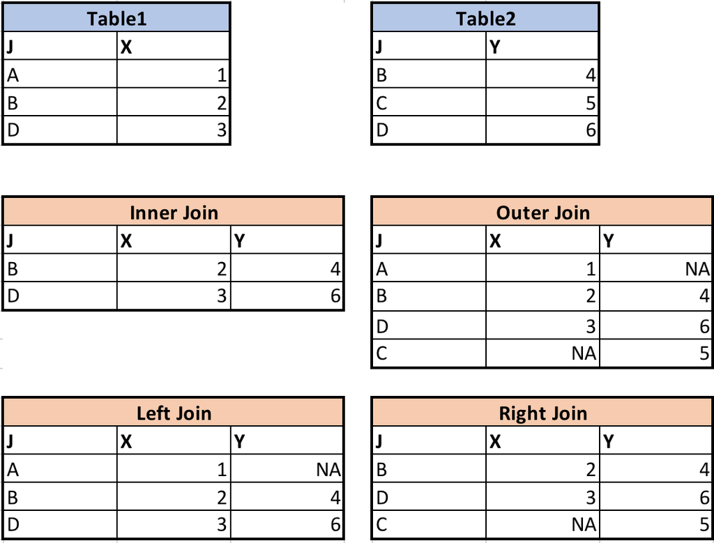

# Let’s get started 🚀

## Entity relationship diagrams

- First, let’s load the libraries and data we will use today

```python
import numpy as np
import pandas as pd

results_raw  = pd.read_csv("data_raw/results.csv")
races_raw    = pd.read_csv("data_raw/races.csv")
circuits_raw = pd.read_csv("data_raw/circuits.csv")
```

- Multi-file datasets can be visualised with an [Entity Relationship Diagram](https://en.wikipedia.org/wiki/Entity%E2%80%93relationship_model)
- An entity represents people, concepts, or events about which data are stored
- An attribute is a property or characteristic of an entity, such as a name or date
- A relationship is an association between entities, which can be one-to-one, one-to-many, or many-to-many

| Type | Description | Example |
| --- | --- | --- |
| One-to-One | One entity relates to exactly one other entity | One student, one mailing address |
| One-to-Many | One entity relates to multiple instances of another entity | One store, many departments |
| Many-to-Many | Multiple instances of both entities relate to each other | Students and courses |

## Entity relationship diagrams

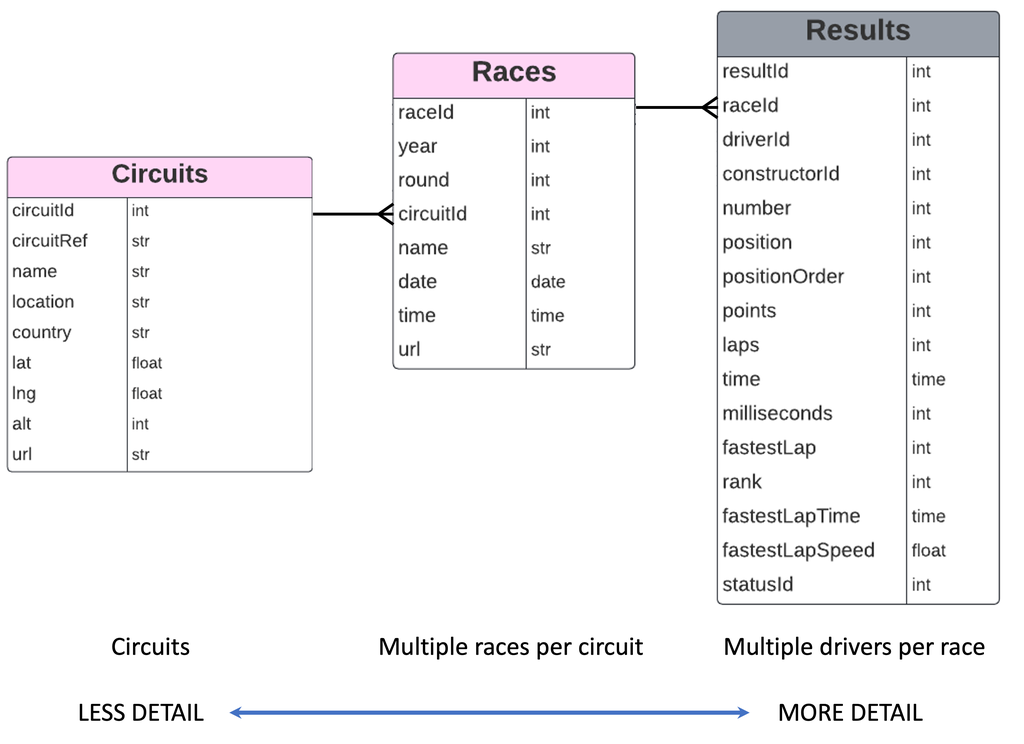

## Let’s have a look at the data 📊

```python
results_raw.head(10)
```

|  | resultId | raceId | driverId | constructorId | number | grid | position | positionText | positionOrder | points | laps | time | milliseconds | fastestLap | rank | fastestLapTime | fastestLapSpeed | statusId |
| --- | --- | --- | --- | --- | --- | --- | --- | --- | --- | --- | --- | --- | --- | --- | --- | --- | --- | --- |
| 0 | 1 | 18 | 1 | 1 | 22 | 1 | 1 | 1 | 1 | 10.0 | 58 | 1:34:50.616 | 5690616 | 39 | 2 | 1:27.452 | 218.300 | 1 |
| 1 | 2 | 18 | 2 | 2 | 3 | 5 | 2 | 2 | 2 | 8.0 | 58 | +5.478 | 5696094 | 41 | 3 | 1:27.739 | 217.586 | 1 |
| 2 | 3 | 18 | 3 | 3 | 7 | 7 | 3 | 3 | 3 | 6.0 | 58 | +8.163 | 5698779 | 41 | 5 | 1:28.090 | 216.719 | 1 |
| 3 | 4 | 18 | 4 | 4 | 5 | 11 | 4 | 4 | 4 | 5.0 | 58 | +17.181 | 5707797 | 58 | 7 | 1:28.603 | 215.464 | 1 |
| 4 | 5 | 18 | 5 | 1 | 23 | 3 | 5 | 5 | 5 | 4.0 | 58 | +18.014 | 5708630 | 43 | 1 | 1:27.418 | 218.385 | 1 |
| 5 | 6 | 18 | 6 | 3 | 8 | 13 | 6 | 6 | 6 | 3.0 | 57 | \N | \N | 50 | 14 | 1:29.639 | 212.974 | 11 |
| 6 | 7 | 18 | 7 | 5 | 14 | 17 | 7 | 7 | 7 | 2.0 | 55 | \N | \N | 22 | 12 | 1:29.534 | 213.224 | 5 |
| 7 | 8 | 18 | 8 | 6 | 1 | 15 | 8 | 8 | 8 | 1.0 | 53 | \N | \N | 20 | 4 | 1:27.903 | 217.180 | 5 |
| 8 | 9 | 18 | 9 | 2 | 4 | 2 | \N | R | 9 | 0.0 | 47 | \N | \N | 15 | 9 | 1:28.753 | 215.100 | 4 |
| 9 | 10 | 18 | 10 | 7 | 12 | 18 | \N | R | 10 | 0.0 | 43 | \N | \N | 23 | 13 | 1:29.558 | 213.166 | 3 |

## Let’s have a look at the data 📊

```python
races_raw.head(10)
```

|  | raceId | year | round | circuitId | name | date | time | url | fp1_date | fp1_time | fp2_date | fp2_time | fp3_date | fp3_time | quali_date | quali_time | sprint_date | sprint_time |
| --- | --- | --- | --- | --- | --- | --- | --- | --- | --- | --- | --- | --- | --- | --- | --- | --- | --- | --- |
| 0 | 1 | 2009 | 1 | 1 | Australian Grand Prix | 2009-03-29 | 06:00:00 | http://en.wikipedia.org/wiki/2009_Australian_G... | \N | \N | \N | \N | \N | \N | \N | \N | \N | \N |
| 1 | 2 | 2009 | 2 | 2 | Malaysian Grand Prix | 2009-04-05 | 09:00:00 | http://en.wikipedia.org/wiki/2009_Malaysian_Gr... | \N | \N | \N | \N | \N | \N | \N | \N | \N | \N |
| 2 | 3 | 2009 | 3 | 17 | Chinese Grand Prix | 2009-04-19 | 07:00:00 | http://en.wikipedia.org/wiki/2009_Chinese_Gran... | \N | \N | \N | \N | \N | \N | \N | \N | \N | \N |
| 3 | 4 | 2009 | 4 | 3 | Bahrain Grand Prix | 2009-04-26 | 12:00:00 | http://en.wikipedia.org/wiki/2009_Bahrain_Gran... | \N | \N | \N | \N | \N | \N | \N | \N | \N | \N |
| 4 | 5 | 2009 | 5 | 4 | Spanish Grand Prix | 2009-05-10 | 12:00:00 | http://en.wikipedia.org/wiki/2009_Spanish_Gran... | \N | \N | \N | \N | \N | \N | \N | \N | \N | \N |
| 5 | 6 | 2009 | 6 | 6 | Monaco Grand Prix | 2009-05-24 | 12:00:00 | http://en.wikipedia.org/wiki/2009_Monaco_Grand... | \N | \N | \N | \N | \N | \N | \N | \N | \N | \N |
| 6 | 7 | 2009 | 7 | 5 | Turkish Grand Prix | 2009-06-07 | 12:00:00 | http://en.wikipedia.org/wiki/2009_Turkish_Gran... | \N | \N | \N | \N | \N | \N | \N | \N | \N | \N |
| 7 | 8 | 2009 | 8 | 9 | British Grand Prix | 2009-06-21 | 12:00:00 | http://en.wikipedia.org/wiki/2009_British_Gran... | \N | \N | \N | \N | \N | \N | \N | \N | \N | \N |
| 8 | 9 | 2009 | 9 | 20 | German Grand Prix | 2009-07-12 | 12:00:00 | http://en.wikipedia.org/wiki/2009_German_Grand... | \N | \N | \N | \N | \N | \N | \N | \N | \N | \N |
| 9 | 10 | 2009 | 10 | 11 | Hungarian Grand Prix | 2009-07-26 | 12:00:00 | http://en.wikipedia.org/wiki/2009_Hungarian_Gr... | \N | \N | \N | \N | \N | \N | \N | \N | \N | \N |

## Let’s have a look at the data 📊

```python
circuits_raw.head(10)
```

|  | circuitId | circuitRef | name | location | country | lat | lng | alt | url |
| --- | --- | --- | --- | --- | --- | --- | --- | --- | --- |
| 0 | 1 | albert_park | Albert Park Grand Prix Circuit | Melbourne | Australia | -37.84970 | 144.96800 | 10 | http://en.wikipedia.org/wiki/Melbourne_Grand_P... |
| 1 | 2 | sepang | Sepang International Circuit | Kuala Lumpur | Malaysia | 2.76083 | 101.73800 | 18 | http://en.wikipedia.org/wiki/Sepang_Internatio... |
| 2 | 3 | bahrain | Bahrain International Circuit | Sakhir | Bahrain | 26.03250 | 50.51060 | 7 | http://en.wikipedia.org/wiki/Bahrain_Internati... |
| 3 | 4 | catalunya | Circuit de Barcelona-Catalunya | Montmeló | Spain | 41.57000 | 2.26111 | 109 | http://en.wikipedia.org/wiki/Circuit_de_Barcel... |
| 4 | 5 | istanbul | Istanbul Park | Istanbul | Turkey | 40.95170 | 29.40500 | 130 | http://en.wikipedia.org/wiki/Istanbul_Park |
| 5 | 6 | monaco | Circuit de Monaco | Monte-Carlo | Monaco | 43.73470 | 7.42056 | 7 | http://en.wikipedia.org/wiki/Circuit_de_Monaco |
| 6 | 7 | villeneuve | Circuit Gilles Villeneuve | Montreal | Canada | 45.50000 | -73.52280 | 13 | http://en.wikipedia.org/wiki/Circuit_Gilles_Vi... |
| 7 | 8 | magny_cours | Circuit de Nevers Magny-Cours | Magny Cours | France | 46.86420 | 3.16361 | 228 | http://en.wikipedia.org/wiki/Circuit_de_Nevers... |
| 8 | 9 | silverstone | Silverstone Circuit | Silverstone | UK | 52.07860 | -1.01694 | 153 | http://en.wikipedia.org/wiki/Silverstone_Circuit |
| 9 | 10 | hockenheimring | Hockenheimring | Hockenheim | Germany | 49.32780 | 8.56583 | 103 | http://en.wikipedia.org/wiki/Hockenheimring |

## Let’s have a look at the data 📊

- We extract all the unique values in `races_raw["name"]` and `circuits_raw["name"]`
- We use `sort_values()` to make it easier to compare the variables

```python
unique_data_races = pd.unique(races_raw["name"].sort_values())
print(unique_data_races)
```

```
['70th Anniversary Grand Prix' 'Abu Dhabi Grand Prix'
 'Argentine Grand Prix' 'Australian Grand Prix' 'Austrian Grand Prix'
 'Azerbaijan Grand Prix' 'Bahrain Grand Prix' 'Belgian Grand Prix'
 'Brazilian Grand Prix' 'British Grand Prix' 'Caesars Palace Grand Prix'
 'Canadian Grand Prix' 'Chinese Grand Prix' 'Dallas Grand Prix'
 'Detroit Grand Prix' 'Dutch Grand Prix' 'Eifel Grand Prix'
 'Emilia Romagna Grand Prix' 'European Grand Prix' 'French Grand Prix'
 'German Grand Prix' 'Hungarian Grand Prix' 'Indian Grand Prix'
 'Indianapolis 500' 'Italian Grand Prix' 'Japanese Grand Prix'
 'Korean Grand Prix' 'Las Vegas Grand Prix' 'Luxembourg Grand Prix'
 'Malaysian Grand Prix' 'Mexican Grand Prix' 'Mexico City Grand Prix'
 'Miami Grand Prix' 'Monaco Grand Prix' 'Moroccan Grand Prix'
 'Pacific Grand Prix' 'Pescara Grand Prix' 'Portuguese Grand Prix'
 'Qatar Grand Prix' 'Russian Grand Prix' 'Sakhir Grand Prix'
 'San Marino Grand Prix' 'Saudi Arabian Grand Prix' 'Singapore Grand Prix'
 'South African Grand Prix' 'Spanish Grand Prix' 'Styrian Grand Prix'
 'Swedish Grand Prix' 'Swiss Grand Prix' 'São Paulo Grand Prix'
 'Turkish Grand Prix' 'Tuscan Grand Prix' 'United States Grand Prix'
 'United States Grand Prix West']
```

## Let’s have a look at the data 📊

- We do the same for the `circuits_raw["name"]` variable

```python
unique_data_circuits = pd.unique(circuits_raw["name"].sort_values())
print(unique_data_circuits)
```

```
['AVUS' 'Adelaide Street Circuit' 'Ain Diab' 'Aintree'
 'Albert Park Grand Prix Circuit' 'Autodromo Enzo e Dino Ferrari'
 'Autodromo Internazionale del Mugello' 'Autodromo Nazionale di Monza'
 'Autódromo Hermanos Rodríguez' 'Autódromo Internacional Nelson Piquet'
 'Autódromo Internacional do Algarve' 'Autódromo José Carlos Pace'
 'Autódromo Juan y Oscar Gálvez' 'Autódromo do Estoril'
 'Bahrain International Circuit' 'Baku City Circuit' 'Brands Hatch'
 'Buddh International Circuit' 'Charade Circuit' 'Circuit Bremgarten'
 'Circuit Gilles Villeneuve' 'Circuit Mont-Tremblant'
 'Circuit Park Zandvoort' 'Circuit Paul Ricard'
 'Circuit de Barcelona-Catalunya' 'Circuit de Monaco'
 'Circuit de Nevers Magny-Cours' 'Circuit de Pedralbes'
 'Circuit de Spa-Francorchamps' 'Circuit of the Americas'
 'Circuito da Boavista' 'Circuito de Jerez' 'Detroit Street Circuit'
 'Dijon-Prenois' 'Donington Park' 'Fair Park' 'Fuji Speedway'
 'Hockenheimring' 'Hungaroring' 'Indianapolis Motor Speedway'
 'Istanbul Park' 'Jarama' 'Jeddah Corniche Circuit'
 'Korean International Circuit' 'Kyalami' 'Las Vegas Street Circuit'
 'Las Vegas Strip Street Circuit' 'Le Mans' 'Long Beach'
 'Losail International Circuit' 'Marina Bay Street Circuit'
 'Miami International Autodrome' 'Monsanto Park Circuit' 'Montjuïc'
 'Mosport International Raceway' 'Nivelles-Baulers' 'Nürburgring'
 'Okayama International Circuit' 'Pescara Circuit'
 'Phoenix street circuit' 'Prince George Circuit' 'Red Bull Ring'
 'Reims-Gueux' 'Riverside International Raceway' 'Rouen-Les-Essarts'
 'Scandinavian Raceway' 'Sebring International Raceway'
 'Sepang International Circuit' 'Shanghai International Circuit'
 'Silverstone Circuit' 'Sochi Autodrom' 'Suzuka Circuit'
 'Valencia Street Circuit' 'Watkins Glen' 'Yas Marina Circuit' 'Zeltweg'
 'Zolder']
```

## Hmmm, the columns are not the same 🤔

- We can see that the names in the `races_raw` and `circuits_raw` datasets are different
- We should rename the columns to ensure we’re not merging the wrong data or creating duplicates
- We can use the [`rename()`](https://pandas.pydata.org/pandas-docs/stable/reference/api/pandas.DataFrame.rename.html) method to do this
- But first we need to understand [what a dictionary is and how it can be used in Python](https://www.w3schools.com/python/python_dictionaries.asp)

# Dictionaries in Python 📚

## What is a dictionary?

- A dictionary is a collection of key-value pairs
- Each key in a dictionary is unique and maps to a value
- You can access values by referencing their keys using square brackets (`[]`)
- Dictionaries are defined using curly braces `{}` with key-value pairs separated by colons (`:`)
- Fields are separated by commas (`,`)
- Example of a dictionary: `my_dict = {"name": "Danilo", "course": "QTM151", "city": "Atlanta"}`
- You can add, modify, or delete key-value pairs in a dictionary
- Dictionaries are mutable, meaning they can be changed after creation

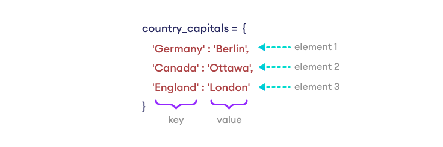

[figure not shown]

## Dictionaries + Pandas

- Let’s create a dictionary in Python

```python
car_dictionary = {"car_model": ["Ferrari","Tesla","BMW"],
                  "year": ["2018","2023","2022"]}
car_dictionary
```

```
{'car_model': ['Ferrari', 'Tesla', 'BMW'], 'year': ['2018', '2023', '2022']}
```

- Dictionaries can have any data type as values, including lists or arrays (even other dictionaries!)

```python
matrix_dict = {'A':np.array([[1,2,3], [2,4,5]]), 'string': 'ABC'}
matrix_dict
```

```
{'A': array([[1, 2, 3],
        [2, 4, 5]]),
 'string': 'ABC'}
```

- We can subset a dictionary using the key

```python
car_dictionary['car_model']
```

```
['Ferrari', 'Tesla', 'BMW']
```

- We can also add new key-value pairs to a dictionary

```python
car_dictionary['colour'] = ["red","blue","black"]
car_dictionary
```

```
{'car_model': ['Ferrari', 'Tesla', 'BMW'],
 'year': ['2018', '2023', '2022'],
 'colour': ['red', 'blue', 'black']}
```

- We can delete key-value pairs using the `del` keyword

```python
del car_dictionary['colour']
car_dictionary.keys()
```

```
dict_keys(['car_model', 'year'])
```

- To create a Pandas DataFrame from a dictionary, we use the `pd.DataFrame()` function

```python
car_dictionary = {"car_model": ["Ferrari","Tesla","BMW","Something"],
                  "year": ["2018","2023","2022", "1993"]}

df = pd.DataFrame(car_dictionary)
df
```

|  | car_model | year |
| --- | --- | --- |
| 0 | Ferrari | 2018 |
| 1 | Tesla | 2023 |
| 2 | BMW | 2022 |
| 3 | Something | 1993 |

## Let’s rename the columns 🔄

- We rename columns with a dictionary using the `{old_name: new_name}` format
- We pass the dictionary to the `rename()` method using the `columns` argument

```python
circuits_raw.rename(columns={'name':'circuit_name'})
```

|  | circuitId | circuitRef | circuit_name | location | country | lat | lng | alt | url |
| --- | --- | --- | --- | --- | --- | --- | --- | --- | --- |
| 0 | 1 | albert_park | Albert Park Grand Prix Circuit | Melbourne | Australia | -37.84970 | 144.96800 | 10 | http://en.wikipedia.org/wiki/Melbourne_Grand_P... |
| 1 | 2 | sepang | Sepang International Circuit | Kuala Lumpur | Malaysia | 2.76083 | 101.73800 | 18 | http://en.wikipedia.org/wiki/Sepang_Internatio... |
| 2 | 3 | bahrain | Bahrain International Circuit | Sakhir | Bahrain | 26.03250 | 50.51060 | 7 | http://en.wikipedia.org/wiki/Bahrain_Internati... |
| 3 | 4 | catalunya | Circuit de Barcelona-Catalunya | Montmeló | Spain | 41.57000 | 2.26111 | 109 | http://en.wikipedia.org/wiki/Circuit_de_Barcel... |
| 4 | 5 | istanbul | Istanbul Park | Istanbul | Turkey | 40.95170 | 29.40500 | 130 | http://en.wikipedia.org/wiki/Istanbul_Park |
| ... | ... | ... | ... | ... | ... | ... | ... | ... | ... |
| 72 | 75 | portimao | Autódromo Internacional do Algarve | Portimão | Portugal | 37.22700 | -8.62670 | 108 | http://en.wikipedia.org/wiki/Algarve_Internati... |
| 73 | 76 | mugello | Autodromo Internazionale del Mugello | Mugello | Italy | 43.99750 | 11.37190 | 255 | http://en.wikipedia.org/wiki/Mugello_Circuit |
| 74 | 77 | jeddah | Jeddah Corniche Circuit | Jeddah | Saudi Arabia | 21.63190 | 39.10440 | 15 | http://en.wikipedia.org/wiki/Jeddah_Street_Cir... |
| 75 | 78 | losail | Losail International Circuit | Al Daayen | Qatar | 25.49000 | 51.45420 | \N | http://en.wikipedia.org/wiki/Losail_Internatio... |
| 76 | 79 | miami | Miami International Autodrome | Miami | USA | 25.95810 | -80.23890 | \N | http://en.wikipedia.org/wiki/Miami_Internation... |

77 rows × 9 columns

## Let’s rename the columns 🔄

- Let’s save the changes to a new `circuits` DataFrame

```python
dict_rename_circuits = {"name": "circuit_name"}
circuits = circuits_raw.rename(columns = dict_rename_circuits)
circuits.head()
```

|  | circuitId | circuitRef | circuit_name | location | country | lat | lng | alt | url |
| --- | --- | --- | --- | --- | --- | --- | --- | --- | --- |
| 0 | 1 | albert_park | Albert Park Grand Prix Circuit | Melbourne | Australia | -37.84970 | 144.96800 | 10 | http://en.wikipedia.org/wiki/Melbourne_Grand_P... |
| 1 | 2 | sepang | Sepang International Circuit | Kuala Lumpur | Malaysia | 2.76083 | 101.73800 | 18 | http://en.wikipedia.org/wiki/Sepang_Internatio... |
| 2 | 3 | bahrain | Bahrain International Circuit | Sakhir | Bahrain | 26.03250 | 50.51060 | 7 | http://en.wikipedia.org/wiki/Bahrain_Internati... |
| 3 | 4 | catalunya | Circuit de Barcelona-Catalunya | Montmeló | Spain | 41.57000 | 2.26111 | 109 | http://en.wikipedia.org/wiki/Circuit_de_Barcel... |
| 4 | 5 | istanbul | Istanbul Park | Istanbul | Turkey | 40.95170 | 29.40500 | 130 | http://en.wikipedia.org/wiki/Istanbul_Park |

- Let’s see if the columns have been renamed

```python
print(circuits_raw.columns.values)
```

```
['circuitId' 'circuitRef' 'name' 'location' 'country' 'lat' 'lng' 'alt'
 'url']
```

```python
print(circuits.columns.values)
```

```
['circuitId' 'circuitRef' 'circuit_name' 'location' 'country' 'lat' 'lng'
 'alt' 'url']
```

- It has worked! 🎉

## Try it yourself! 🧠

- Create a dictionary to rename `name` to `race_name`
- Rename this column in the `races_raw` dataset
- Store the output in a new dataset called `races`
- Appendix 01

# Merge data in Pandas 🔄

## Using `pd.merge()` to combine data

- We can use the [`pd.merge()`](https://pandas.pydata.org/pandas-docs/stable/reference/api/pandas.merge.html) function to combine data
- First, we need to extract the columns we want to merge and the type of join we want to perform
- The `on` argument specifies the column to merge on
- The `how` argument specifies the type of join to perform

```python
circuits[["circuitId","circuit_name"]].head()
```

|  | circuitId | circuit_name |
| --- | --- | --- |
| 0 | 1 | Albert Park Grand Prix Circuit |
| 1 | 2 | Sepang International Circuit |
| 2 | 3 | Bahrain International Circuit |
| 3 | 4 | Circuit de Barcelona-Catalunya |
| 4 | 5 | Istanbul Park |

```python
circuits.shape[0] # rows
```

```
77
```

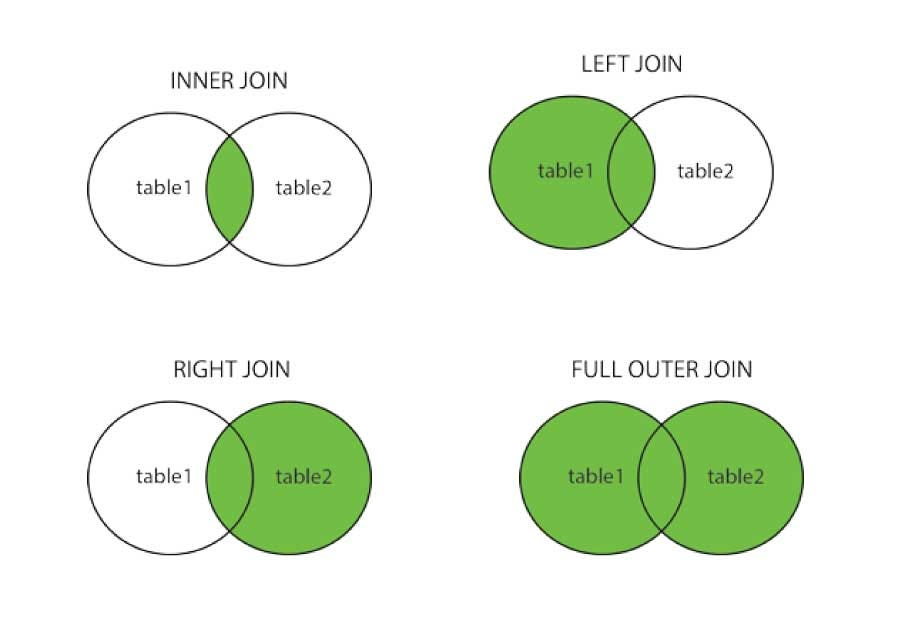

## Using `pd.merge()` to combine data

- `pd.merge(data1, data2, on, how)`
- Strive to merge only specific columns of `data2`
- Avoid merging all columns
- Keeping it simple gives you more control over the output

```python
# The "pd.merge()" command combines the information from both datasets
# The first argument is the "primary" datasets
# The second argument is the "secondary" dataset (must include the "on" column)
# The "on" is the common variable that is used for merging
# how = "left" tells Python that the left dataset is the primary one

races_merge = pd.merge(races_raw[['raceId', 'year', 'circuitId']],
                       circuits[["circuitId","circuit_name", "location"]],
                       on = "circuitId",
                       how = "left")
```

## Using `pd.merge()` to combine data

- Let’s see the results of the merge

```python
races_merge
```

|  | raceId | year | circuitId | circuit_name | location |
| --- | --- | --- | --- | --- | --- |
| 0 | 1 | 2009 | 1 | Albert Park Grand Prix Circuit | Melbourne |
| 1 | 2 | 2009 | 2 | Sepang International Circuit | Kuala Lumpur |
| 2 | 3 | 2009 | 17 | Shanghai International Circuit | Shanghai |
| 3 | 4 | 2009 | 3 | Bahrain International Circuit | Sakhir |
| 4 | 5 | 2009 | 4 | Circuit de Barcelona-Catalunya | Montmeló |
| ... | ... | ... | ... | ... | ... |
| 1097 | 1116 | 2023 | 69 | Circuit of the Americas | Austin |
| 1098 | 1117 | 2023 | 32 | Autódromo Hermanos Rodríguez | Mexico City |
| 1099 | 1118 | 2023 | 18 | Autódromo José Carlos Pace | São Paulo |
| 1100 | 1119 | 2023 | 80 | Las Vegas Strip Street Circuit | Las Vegas |
| 1101 | 1120 | 2023 | 24 | Yas Marina Circuit | Abu Dhabi |

1102 rows × 5 columns

## Using `pd.merge()` to combine data

- We can extract the columns we want to see

```python
races_merge[["raceId",  "circuitId","circuit_name"]].sort_values(by = "circuit_name")
```

|  | raceId | circuitId | circuit_name |
| --- | --- | --- | --- |
| 760 | 761 | 61 | AVUS |
| 434 | 435 | 29 | Adelaide Street Circuit |
| 335 | 336 | 29 | Adelaide Street Circuit |
| 319 | 320 | 29 | Adelaide Street Circuit |
| 370 | 371 | 29 | Adelaide Street Circuit |
| ... | ... | ... | ... |
| 501 | 502 | 40 | Zolder |
| 486 | 487 | 40 | Zolder |
| 470 | 471 | 40 | Zolder |
| 516 | 517 | 40 | Zolder |
| 608 | 609 | 40 | Zolder |

1102 rows × 3 columns

- Another example of a merge

```python
results_merge = pd.merge(results_raw,
                         races_raw[["raceId","date"]],
                         on = "raceId",
                         how = "left")

results_merge.head()
```

|  | resultId | raceId | driverId | constructorId | number | grid | position | positionText | positionOrder | points | laps | time | milliseconds | fastestLap | rank | fastestLapTime | fastestLapSpeed | statusId | date |
| --- | --- | --- | --- | --- | --- | --- | --- | --- | --- | --- | --- | --- | --- | --- | --- | --- | --- | --- | --- |
| 0 | 1 | 18 | 1 | 1 | 22 | 1 | 1 | 1 | 1 | 10.0 | 58 | 1:34:50.616 | 5690616 | 39 | 2 | 1:27.452 | 218.300 | 1 | 2008-03-16 |
| 1 | 2 | 18 | 2 | 2 | 3 | 5 | 2 | 2 | 2 | 8.0 | 58 | +5.478 | 5696094 | 41 | 3 | 1:27.739 | 217.586 | 1 | 2008-03-16 |
| 2 | 3 | 18 | 3 | 3 | 7 | 7 | 3 | 3 | 3 | 6.0 | 58 | +8.163 | 5698779 | 41 | 5 | 1:28.090 | 216.719 | 1 | 2008-03-16 |
| 3 | 4 | 18 | 4 | 4 | 5 | 11 | 4 | 4 | 4 | 5.0 | 58 | +17.181 | 5707797 | 58 | 7 | 1:28.603 | 215.464 | 1 | 2008-03-16 |
| 4 | 5 | 18 | 5 | 1 | 23 | 3 | 5 | 5 | 5 | 4.0 | 58 | +18.014 | 5708630 | 43 | 1 | 1:27.418 | 218.385 | 1 | 2008-03-16 |

## Common pitfall: What happens if you don’t rename the columns?

- If you don’t rename the columns, you may end up with duplicate columns
- This can make it difficult to understand the data
- It can also lead to errors when merging data
- The following code merges the raw data which has the `name` column in `races_raw` and `circuits_raw`

```python
races_merge_pitfall = pd.merge(races_raw,
                               circuits_raw[["circuitId","name"]],
                               on = "circuitId",
                               how = "left")
```

- Let’s see the results of the merge

```python
print(races_merge_pitfall.columns.values)
```

```
['raceId' 'year' 'round' 'circuitId' 'name_x' 'date' 'time' 'url'
 'fp1_date' 'fp1_time' 'fp2_date' 'fp2_time' 'fp3_date' 'fp3_time'
 'quali_date' 'quali_time' 'sprint_date' 'sprint_time' 'name_y']
```

- We can see that the `name` column has been duplicated
- Python appends `_x` and `_y` to the column names to differentiate them

## Try it yourself! 🧠

- Rename the columns `name_x` and `name_y` in the dataset `races_merge_pitfall` to `race_name` and `circuit_name`
- HINT: Create a dictionary and use `.rename()`
- Appendix 02

## Try it yourself! 🧠

- Merge the column `alt`, `lng`, and `lat` into the `races` data using `pd.merge()`
- HINT: Use the `circuitId` as the key
- Appendix 03

## Concatenating data in Pandas

### `pd.concat()`

- We can use the [`pd.concat()`](https://pandas.pydata.org/pandas-docs/stable/reference/api/pandas.concat.html) function to concatenate data
- We can concatenate data along the rows or columns
- The method works best if columns are identical
- There are also other advanced options if they are not, please check [the documentation for more information](https://pandas.pydata.org/pandas-docs/stable/reference/api/pandas.concat.html)
- Let’s use `.query()` to split the data into different parts

```python
circuits['country'].unique()
```

```
array(['Australia', 'Malaysia', 'Bahrain', 'Spain', 'Turkey', 'Monaco',
       'Canada', 'France', 'UK', 'Germany', 'Hungary', 'Belgium', 'Italy',
       'Singapore', 'Japan', 'China', 'Brazil', 'USA', 'United States',
       'UAE', 'Argentina', 'Portugal', 'South Africa', 'Mexico', 'Korea',
       'Netherlands', 'Sweden', 'Austria', 'Morocco', 'Switzerland',
       'India', 'Russia', 'Azerbaijan', 'Saudi Arabia', 'Qatar'],
      dtype=object)
```

```python
circuits_spain = circuits.query('country == "Spain"')
circuits_usa = circuits.query('country == "United States" | country == "USA"')
circuits_malaysia = circuits.query('country == "Malaysia"')
```

## Concatenating data in Pandas

```python
circuits_concat = pd.concat([circuits_spain, circuits_usa, circuits_malaysia])
circuits_concat.head()
```

|  | circuitId | circuitRef | circuit_name | location | country | lat | lng | alt | url |
| --- | --- | --- | --- | --- | --- | --- | --- | --- | --- |
| 3 | 4 | catalunya | Circuit de Barcelona-Catalunya | Montmeló | Spain | 41.5700 | 2.261110 | 109 | http://en.wikipedia.org/wiki/Circuit_de_Barcel... |
| 11 | 12 | valencia | Valencia Street Circuit | Valencia | Spain | 39.4589 | -0.331667 | 4 | http://en.wikipedia.org/wiki/Valencia_Street_C... |
| 25 | 26 | jerez | Circuito de Jerez | Jerez de la Frontera | Spain | 36.7083 | -6.034170 | 37 | http://en.wikipedia.org/wiki/Circuito_Permanen... |
| 44 | 45 | jarama | Jarama | Madrid | Spain | 40.6171 | -3.585580 | 609 | http://en.wikipedia.org/wiki/Circuito_Permanen... |
| 48 | 49 | montjuic | Montjuïc | Barcelona | Spain | 41.3664 | 2.151670 | 79 | http://en.wikipedia.org/wiki/Montju%C3%AFc_cir... |

## Concatenating data in Pandas

```python
circuits_spain_drop = circuits_spain.drop(columns=['circuitRef', 'location'])
pd.concat([circuits_spain_drop, circuits_usa])
```

|  | circuitId | circuit_name | country | lat | lng | alt | url | circuitRef | location |
| --- | --- | --- | --- | --- | --- | --- | --- | --- | --- |
| 3 | 4 | Circuit de Barcelona-Catalunya | Spain | 41.5700 | 2.261110 | 109 | http://en.wikipedia.org/wiki/Circuit_de_Barcel... | NaN | NaN |
| 11 | 12 | Valencia Street Circuit | Spain | 39.4589 | -0.331667 | 4 | http://en.wikipedia.org/wiki/Valencia_Street_C... | NaN | NaN |
| 25 | 26 | Circuito de Jerez | Spain | 36.7083 | -6.034170 | 37 | http://en.wikipedia.org/wiki/Circuito_Permanen... | NaN | NaN |
| 44 | 45 | Jarama | Spain | 40.6171 | -3.585580 | 609 | http://en.wikipedia.org/wiki/Circuito_Permanen... | NaN | NaN |
| 48 | 49 | Montjuïc | Spain | 41.3664 | 2.151670 | 79 | http://en.wikipedia.org/wiki/Montju%C3%AFc_cir... | NaN | NaN |
| 66 | 67 | Circuit de Pedralbes | Spain | 41.3903 | 2.116670 | 85 | http://en.wikipedia.org/wiki/Pedralbes_Circuit | NaN | NaN |
| 18 | 19 | Indianapolis Motor Speedway | USA | 39.7950 | -86.234700 | 223 | http://en.wikipedia.org/wiki/Indianapolis_Moto... | indianapolis | Indianapolis |
| 22 | 80 | Las Vegas Strip Street Circuit | United States | 36.1147 | -115.173000 | \N | https://en.wikipedia.org/wiki/Las_Vegas_Grand_... | vegas | Las Vegas |
| 32 | 33 | Phoenix street circuit | USA | 33.4479 | -112.075000 | 345 | http://en.wikipedia.org/wiki/Phoenix_street_ci... | phoenix | Phoenix |
| 36 | 37 | Detroit Street Circuit | USA | 42.3298 | -83.040100 | 177 | http://en.wikipedia.org/wiki/Detroit_street_ci... | detroit | Detroit |
| 41 | 42 | Fair Park | USA | 32.7774 | -96.758700 | 139 | http://en.wikipedia.org/wiki/Fair_Park | dallas | Dallas |
| 42 | 43 | Long Beach | USA | 33.7651 | -118.189000 | 12 | http://en.wikipedia.org/wiki/Long_Beach,_Calif... | long_beach | California |
| 43 | 44 | Las Vegas Street Circuit | USA | 36.1162 | -115.174000 | 639 | http://en.wikipedia.org/wiki/Las_Vegas_Street_... | las_vegas | Nevada |
| 45 | 46 | Watkins Glen | USA | 42.3369 | -76.927200 | 485 | http://en.wikipedia.org/wiki/Watkins_Glen_Inte... | watkins_glen | New York State |
| 59 | 60 | Riverside International Raceway | USA | 33.9370 | -117.273000 | 470 | http://en.wikipedia.org/wiki/Riverside_Interna... | riverside | California |
| 62 | 63 | Sebring International Raceway | USA | 27.4547 | -81.348300 | 18 | http://en.wikipedia.org/wiki/Sebring_Raceway | sebring | Florida |
| 68 | 69 | Circuit of the Americas | USA | 30.1328 | -97.641100 | 161 | http://en.wikipedia.org/wiki/Circuit_of_the_Am... | americas | Austin |
| 76 | 79 | Miami International Autodrome | USA | 25.9581 | -80.238900 | \N | http://en.wikipedia.org/wiki/Miami_Internation... | miami | Miami |

## Try it yourself! 🧠

- Concatenate the USA and Malaysia datasets
- Appendix 04

# And that’s it for today! 🎉

# Have a very nice week! 😊

## Appendix 01

```python
dict_rename = {"name": "race_name"}
races_raw.rename(columns = dict_rename).head()
```

|  | raceId | year | round | circuitId | race_name | date | time | url | fp1_date | fp1_time | fp2_date | fp2_time | fp3_date | fp3_time | quali_date | quali_time | sprint_date | sprint_time |
| --- | --- | --- | --- | --- | --- | --- | --- | --- | --- | --- | --- | --- | --- | --- | --- | --- | --- | --- |
| 0 | 1 | 2009 | 1 | 1 | Australian Grand Prix | 2009-03-29 | 06:00:00 | http://en.wikipedia.org/wiki/2009_Australian_G... | \N | \N | \N | \N | \N | \N | \N | \N | \N | \N |
| 1 | 2 | 2009 | 2 | 2 | Malaysian Grand Prix | 2009-04-05 | 09:00:00 | http://en.wikipedia.org/wiki/2009_Malaysian_Gr... | \N | \N | \N | \N | \N | \N | \N | \N | \N | \N |
| 2 | 3 | 2009 | 3 | 17 | Chinese Grand Prix | 2009-04-19 | 07:00:00 | http://en.wikipedia.org/wiki/2009_Chinese_Gran... | \N | \N | \N | \N | \N | \N | \N | \N | \N | \N |
| 3 | 4 | 2009 | 4 | 3 | Bahrain Grand Prix | 2009-04-26 | 12:00:00 | http://en.wikipedia.org/wiki/2009_Bahrain_Gran... | \N | \N | \N | \N | \N | \N | \N | \N | \N | \N |
| 4 | 5 | 2009 | 5 | 4 | Spanish Grand Prix | 2009-05-10 | 12:00:00 | http://en.wikipedia.org/wiki/2009_Spanish_Gran... | \N | \N | \N | \N | \N | \N | \N | \N | \N | \N |

```python
races = races_raw.rename(columns = dict_rename)
races.columns
```

```
Index(['raceId', 'year', 'round', 'circuitId', 'race_name', 'date', 'time',
       'url', 'fp1_date', 'fp1_time', 'fp2_date', 'fp2_time', 'fp3_date',
       'fp3_time', 'quali_date', 'quali_time', 'sprint_date', 'sprint_time'],
      dtype='object')
```

Back to Exercise 01

## Appendix 02

```python
rename = {"name_x": "race_name", "name_y": "circuit_name"}
races_merge_pitfall.rename(columns = rename).info()
```

```
<class 'pandas.core.frame.DataFrame'>
RangeIndex: 1102 entries, 0 to 1101
Data columns (total 19 columns):
 #   Column        Non-Null Count  Dtype
---  ------        --------------  -----
 0   raceId        1102 non-null   int64
 1   year          1102 non-null   int64
 2   round         1102 non-null   int64
 3   circuitId     1102 non-null   int64
 4   race_name     1102 non-null   object
 5   date          1102 non-null   object
 6   time          1102 non-null   object
 7   url           1102 non-null   object
 8   fp1_date      1102 non-null   object
 9   fp1_time      1102 non-null   object
 10  fp2_date      1102 non-null   object
 11  fp2_time      1102 non-null   object
 12  fp3_date      1102 non-null   object
 13  fp3_time      1102 non-null   object
 14  quali_date    1102 non-null   object
 15  quali_time    1102 non-null   object
 16  sprint_date   1102 non-null   object
 17  sprint_time   1102 non-null   object
 18  circuit_name  1102 non-null   object
dtypes: int64(4), object(15)
memory usage: 163.7+ KB
```

Back to Exercise 02

## Appendix 03

```python
races02 = pd.merge(races,
                   circuits[["circuitId","alt","lng","lat"]],
                   on = "circuitId",
                   how = "left")
races02.head()
```

|  | raceId | year | round | circuitId | race_name | date | time | url | fp1_date | fp1_time | ... | fp2_time | fp3_date | fp3_time | quali_date | quali_time | sprint_date | sprint_time | alt | lng | lat |
| --- | --- | --- | --- | --- | --- | --- | --- | --- | --- | --- | --- | --- | --- | --- | --- | --- | --- | --- | --- | --- | --- |
| 0 | 1 | 2009 | 1 | 1 | Australian Grand Prix | 2009-03-29 | 06:00:00 | http://en.wikipedia.org/wiki/2009_Australian_G... | \N | \N | ... | \N | \N | \N | \N | \N | \N | \N | 10 | 144.96800 | -37.84970 |
| 1 | 2 | 2009 | 2 | 2 | Malaysian Grand Prix | 2009-04-05 | 09:00:00 | http://en.wikipedia.org/wiki/2009_Malaysian_Gr... | \N | \N | ... | \N | \N | \N | \N | \N | \N | \N | 18 | 101.73800 | 2.76083 |
| 2 | 3 | 2009 | 3 | 17 | Chinese Grand Prix | 2009-04-19 | 07:00:00 | http://en.wikipedia.org/wiki/2009_Chinese_Gran... | \N | \N | ... | \N | \N | \N | \N | \N | \N | \N | 5 | 121.22000 | 31.33890 |
| 3 | 4 | 2009 | 4 | 3 | Bahrain Grand Prix | 2009-04-26 | 12:00:00 | http://en.wikipedia.org/wiki/2009_Bahrain_Gran... | \N | \N | ... | \N | \N | \N | \N | \N | \N | \N | 7 | 50.51060 | 26.03250 |
| 4 | 5 | 2009 | 5 | 4 | Spanish Grand Prix | 2009-05-10 | 12:00:00 | http://en.wikipedia.org/wiki/2009_Spanish_Gran... | \N | \N | ... | \N | \N | \N | \N | \N | \N | \N | 109 | 2.26111 | 41.57000 |

5 rows × 21 columns

Back to Exercise 03

## Appendix 04

```python
circuits_usa_malaysia = pd.concat([circuits_usa, circuits_malaysia])
circuits_usa_malaysia.head()
```

|  | circuitId | circuitRef | circuit_name | location | country | lat | lng | alt | url |
| --- | --- | --- | --- | --- | --- | --- | --- | --- | --- |
| 18 | 19 | indianapolis | Indianapolis Motor Speedway | Indianapolis | USA | 39.7950 | -86.2347 | 223 | http://en.wikipedia.org/wiki/Indianapolis_Moto... |
| 22 | 80 | vegas | Las Vegas Strip Street Circuit | Las Vegas | United States | 36.1147 | -115.1730 | \N | https://en.wikipedia.org/wiki/Las_Vegas_Grand_... |
| 32 | 33 | phoenix | Phoenix street circuit | Phoenix | USA | 33.4479 | -112.0750 | 345 | http://en.wikipedia.org/wiki/Phoenix_street_ci... |
| 36 | 37 | detroit | Detroit Street Circuit | Detroit | USA | 42.3298 | -83.0401 | 177 | http://en.wikipedia.org/wiki/Detroit_street_ci... |
| 41 | 42 | dallas | Fair Park | Dallas | USA | 32.7774 | -96.7587 | 139 | http://en.wikipedia.org/wiki/Fair_Park |

Back to Exercise 04

[Merging Data](https://raw.githack.com/danilofreire/qtm151/main/lectures/lecture-16/16-merging-data.html)